# ASSIGNMENT 1

AJITH RAJ PERIYASAMY

2024-02-04

# SUMMARY

## NETFLIX USERBASE

### The dataset for the assignment has been sourced from:

#### https://www.kaggle.com/datasets/arnavsmayan/netflix-userbase-dataset

#### The below report depicts the netflix userbase taking into consideration various factors such as subscription type, monthly revenue generated per subscribers, age, gender, etc.

## IMPORTING DATASET

#### The first code illustrates how to import a dataset from web to into ‘R’ studio.

```r
Netflix_Userbase<-read.csv("./Netflix Userbase.csv")
head(Netflix_Userbase)
```

```
##   User.ID Subscription.Type Monthly.Revenue Join.Date Last.Payment.Date
## 1       1             Basic              10  15-01-22          10-06-23
## 2       2           Premium              15  05-09-21          22-06-23
## 3       3          Standard              12  28-02-23          27-06-23
## 4       4          Standard              12  10-07-22          26-06-23
## 5       5             Basic              10  01-05-23          28-06-23
## 6       6           Premium              15  18-03-22          27-06-23
##          Country Age Gender     Device Plan.Duration
## 1  United States  28   Male Smartphone       1 Month
## 2         Canada  35 Female     Tablet       1 Month
## 3 United Kingdom  42   Male   Smart TV       1 Month
## 4      Australia  51 Female     Laptop       1 Month
## 5        Germany  33   Male Smartphone       1 Month
## 6         France  29 Female   Smart TV       1 Month
```

## DESCRIPTIVE STATISTICS FOR QUANTITATIVE AND CATEGORICAL VARIABLES

### QUANTITATIVE VARIABLE

#### In this case it can be inferred that the average monthly revenue generated by netflix through subscription is 12.51.

### CATEGORICAL VARIABLE

#### Here I have assumed age to be the categorical variable and it is evident that the average age of netflix subscribers is 38.8.

```r
summary(Netflix_Userbase[,3])#QUANTITATIVE VARIABLE
```

```
##    Min. 1st Qu.  Median    Mean 3rd Qu.    Max.
##   10.00   11.00   12.00   12.51   14.00   15.00
```

```r
summary(Netflix_Userbase[,7])#CATEGORICAL VARIABLE
```

```
##    Min. 1st Qu.  Median    Mean 3rd Qu.    Max.
##    26.0    32.0    39.0    38.8    45.0    51.0
```

## TRANSFORMING VARIABLE

#### Below I have made an attempt to convert integer datatype elements to character datatype.

```r
as.character(Netflix_Userbase[,3])
```

[output not shown]

[output cut: 164 more lines]

## PLOTTING QUANTITATIVE VARIABLE & SCATTERPLOT

#### The first case shows scatterplots which compares two values i.e, age and monthly revenue.

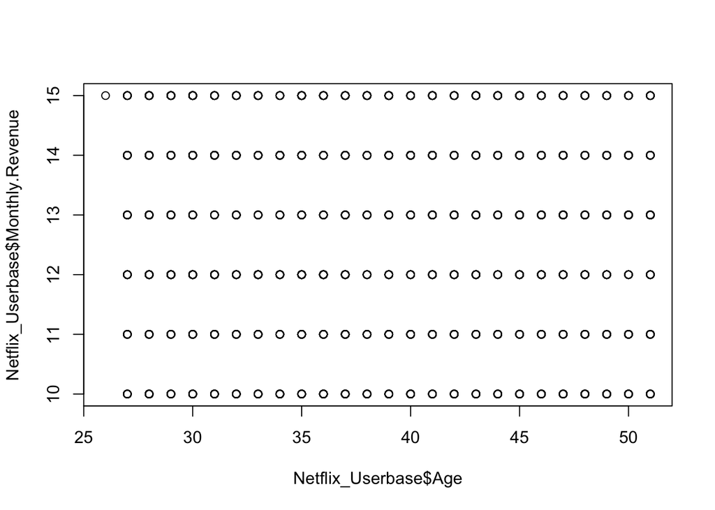

```r
plot(Netflix_Userbase$Age,Netflix_Userbase$Monthly.Revenue)
```

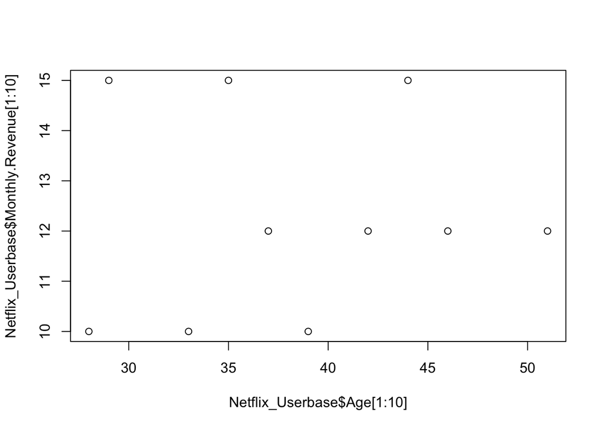

```r
plot(Netflix_Userbase$Age[1:10],Netflix_Userbase$Monthly.Revenue[1:10])
```

```r
#
```

## BAR GRAPH

#### The bar graph below has the type of plans in the X-Axis i.e, Basic, Premium, and Standard and the number of subscibers (Both male and female) in the Y-Axis. It can be inferred that many people have subscribed for the Basic plan than the Premium and the Standard plans.

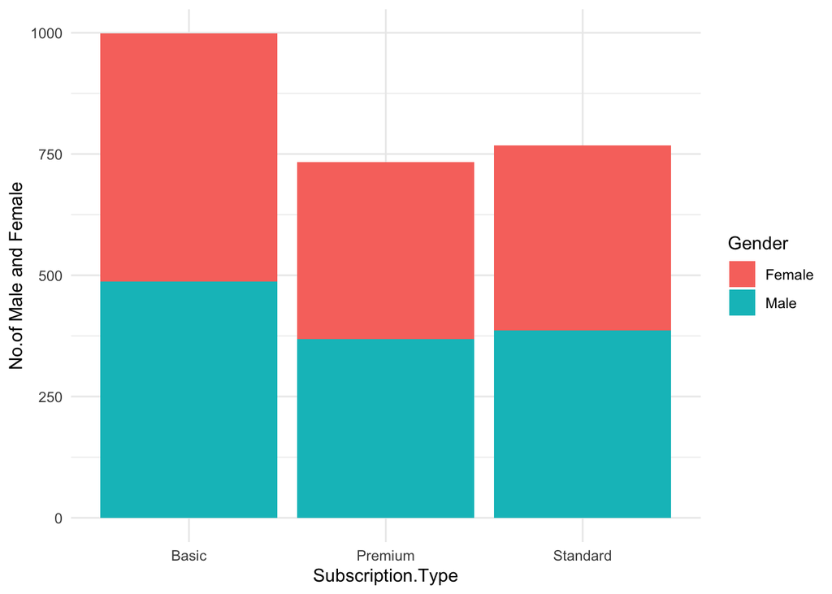

```r
library(ggplot2)

ggplot(Netflix_Userbase) +
 aes(x = Subscription.Type, fill = Gender) +
 geom_bar() +
 scale_fill_hue(direction = 1) +
 labs(y = "No.of Male and Female") +
 theme_minimal()
```